# **Create visualizations using Matplotib, Seaborn and Folium**

Estimated time needed: **40** minutes

In this assignment, you will have the opportunity to demonstrate the skills you have acquired in creating visualizations using *Matplotlib, Seaborn, Folium*.  
After each task you will be required to save your plots as an image or screenshot using the filenames specified. You will be uploading these images during your final project submission so they can be evaluated by your peers.

1. Objectives
2. Setup
   1. Installing Required Libraries
   2. Importing Required Libraries
3. Scenario
   1. Data Description
4. Importing data
5. Creating Visualizations for Data Analysis

# Objectives

After completing this lab you will be able to:

- Create informative and visually appealing plots with Matplotlib and Seaborn.
- Apply visualization to communicate insights from the data.
- Analyze data through using visualizations.
- Customize visualizations

# Setup

For this lab, we will be using the following libraries:

- `pandas` for managing the data.
- [`numpy`](https://numpy.org/?utm_medium=Exinfluencer&utm_source=Exinfluencer&utm_content=000026UJ&utm_term=10006555&utm_id=NA-SkillsNetwork-Channel-SkillsNetworkCoursesIBMML0187ENSkillsNetwork31430127-2021-01-01) for mathematical operations.
- [`matplotlib`](https://matplotlib.org/?utm_medium=Exinfluencer&utm_source=Exinfluencer&utm_content=000026UJ&utm_term=10006555&utm_id=NA-SkillsNetwork-Channel-SkillsNetworkCoursesIBMML0187ENSkillsNetwork31430127-2021-01-01) for plotting.
- `seaborn` for plotting.
- `Folium` for plotting.

### Installing Required Libraries

The following required libraries are pre-installed in the Skills Network Labs environment. However, if you run these notebook commands in a different Jupyter environment (e.g. Watson Studio or Ananconda), you will need to install these libraries by removing the `#` sign before `%pip` in the code cell below.

```python
# All Libraries required for this lab are listed below. The libraries pre-installed on Skills Network Labs are commented.
#!pip install -qy pandas==1.3.4 numpy==1.21.4 matplotlib==3.5.0 seaborn folium
# Note: If your environment doesn't support "%pip install", use "!mamba install"
```

```python
%pip install seaborn
%pip install folium
```

### Importing Required Libraries

*We recommend you import all required libraries in one place (here):*

```python
import numpy as np
import pandas as pd
%matplotlib inline
import matplotlib as mpl
import matplotlib.pyplot as plt
import seaborn as sns
import folium
```

**Click here for a hint**

You will require:-  
Numpy for many scientific computing in Python  
Pandas for creating and working on dataframe, also for plotting directly on dataframe/series  
The inline backend to generate the plots within the browser [%matplotlib inline]  
Matplotlib and its pyplot pacakge for plotting  
Seaborn for plotting

**Click here for python solution**

```
#Import Primary Modules:
    import numpy as np
    import pandas as pd
    %matplotlib inline
    import matplotlib as mpl
    import matplotlib.pyplot as plt
    import seaborn as sns
    import folium
```

# Scenario

In this assignment you will be tasked with creating plots which answer questions for analysing "historical_automobile_sales" data to understand the historical trends in automobile sales during recession periods.  
recession period 1 - year 1980  
recession period 2 - year 1981 to 1982  
recession period 3 - year 1991  
recession period 4 - year 2000 to 2001  
recession period 5 - year end 2007 to mid 2009  
recession period 6 - year 2020 -Feb to April (Covid-19 Impact)

# Data Description

The dataset used for this visualization assignment contains *historical_automobile_sales* data representing automobile sales and related variables during recession and non-recession period.

The dataset includes the following variables:  
1. Date: The date of the observation.  
2. Recession: A binary variable indicating recession perion; 1 means it was recession, 0 means it was normal.  
3. Automobile_Sales: The number of vehicles sold during the period.  
4. GDP: The per capita GDP value in USD.  
5. Unemployment_Rate: The monthly unemployment rate.  
6. Consumer_Confidence: A synthetic index representing consumer confidence, which can impact consumer spending and automobile purchases.  
7. Seasonality_Weight: The weight representing the seasonality effect on automobile sales during the period.  
8. Price: The average vehicle price during the period.  
9. Advertising_Expenditure: The advertising expenditure of the company.  
10.Vehicle_Type: The type of vehicles sold; Supperminicar, Smallfamiliycar, Mediumfamilycar, Executivecar, Sports.  
11.Competition: The measure of competition in the market, such as the number of competitors or market share of major manufacturers.  
12.Month: Month of the observation extracted from Date..  
13.Year: Year of the observation extracted from Date.  
By examining various factors mentioned above from the dataset, you aim to gain insights into how recessions impacted automobile sales for your company.

# Importing Data

#### For your convenience, we have already written code to import the data below.

```python
from js import fetch
import io
import pandas as pd

URL = "https://cf-courses-data.s3.us.cloud-object-storage.appdomain.cloud/IBMDeveloperSkillsNetwork-DV0101EN-SkillsNetwork/Data%20Files/historical_automobile_sales.csv"
resp = await fetch(URL)
text = io.BytesIO((await resp.arrayBuffer()).to_py())

df = pd.read_csv(text)
print('Data downloaded and read into a dataframe!')
```

```python
df = pd.read_csv('historical_automobile_sales.csv')
df.head()
```

|  | Date | Year | Month | Recession | Consumer_Confidence | Seasonality_Weight | Price | Advertising_Expenditure | Competition | GDP | Growth_Rate | unemployment_rate | Automobile_Sales | Vehicle_Type | City |
| --- | --- | --- | --- | --- | --- | --- | --- | --- | --- | --- | --- | --- | --- | --- | --- |
| 0 | 1/31/1980 | 1980 | Jan | 1 | 108.24 | 0.50 | 27483.571 | 1558 | 7 | 60.223 | 0.010000 | 5.4 | 456.0 | Supperminicar | Georgia |
| 1 | 2/29/1980 | 1980 | Feb | 1 | 98.75 | 0.75 | 24308.678 | 3048 | 4 | 45.986 | -0.309594 | 4.8 | 555.9 | Supperminicar | New York |
| 2 | 3/31/1980 | 1980 | Mar | 1 | 107.48 | 0.20 | 28238.443 | 3137 | 3 | 35.141 | -0.308614 | 3.4 | 620.0 | Mediumfamilycar | New York |
| 3 | 4/30/1980 | 1980 | Apr | 1 | 115.01 | 1.00 | 32615.149 | 1653 | 7 | 45.673 | 0.230596 | 4.2 | 702.8 | Supperminicar | Illinois |
| 4 | 5/31/1980 | 1980 | May | 1 | 98.72 | 0.20 | 23829.233 | 1319 | 4 | 52.997 | 0.138197 | 5.3 | 770.4 | Smallfamiliycar | California |

```python
df.columns
```

```
Index(['Date', 'Year', 'Month', 'Recession', 'Consumer_Confidence',
       'Seasonality_Weight', 'Price', 'Advertising_Expenditure', 'Competition',
       'GDP', 'Growth_Rate', 'unemployment_rate', 'Automobile_Sales',
       'Vehicle_Type', 'City'],
      dtype='object')
```

# Creating Visualizations for Data Analysis

### TASK 1.1: Develop a *Line chart* using the functionality of pandas to show how automobile sales fluctuate from year to year

**Click here for a hint**

You will require:-  
to group the year and calculate the average on the 'Automobile Sales', as the data has years and months column  
make use of .plot() with kind = 'line'  
donot forget to include labels and title

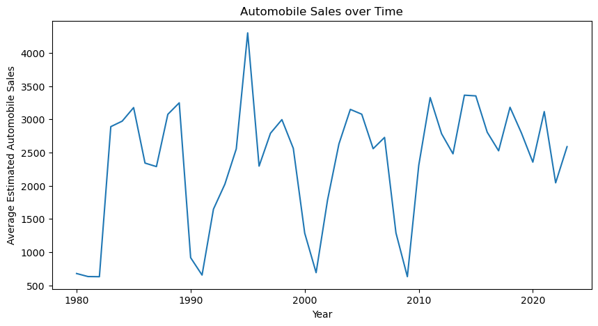

```python
#perform group by on year for average sales
df_new = df.groupby('Year')['Automobile_Sales'].mean().to_frame()
df_new.reset_index(inplace=True)

plt.figure(figsize=(10, 5))
sns.lineplot(data=df_new,x="Year",y="Automobile_Sales")
plt.xlabel('Year')
plt.ylabel('Average Estimated Automobile Sales')
plt.title('Automobile Sales over Time')
plt.show()
```

**Click here for a solution template**

```
#create data for plotting
    df_line = df.groupby(df['Year'])['Automobile_Sales'].mean()
    #create figure
    plt.figure(figsize=(10, 6))
    df_line.plot(kind = 'line')
    plt.xlabel('........')
    plt.ylabel('.........')
    plt.title('......................')
    plt.show()
```

### Include the following on the plot

ticks on x- axis with all the years, to identify the years of recession  
annotation for at least two years of recession  
Title as Automobile Sales during Recession

**Click here for a hint**

You can create the list for the range 1980 till 2023 and pass that list to the plt.xticks function or you can directly pass the range to the function. You might need to rotate the ticks to an angle so that they fit in well on the axis You can include annotation with plt.text(x, y, 'text to display')

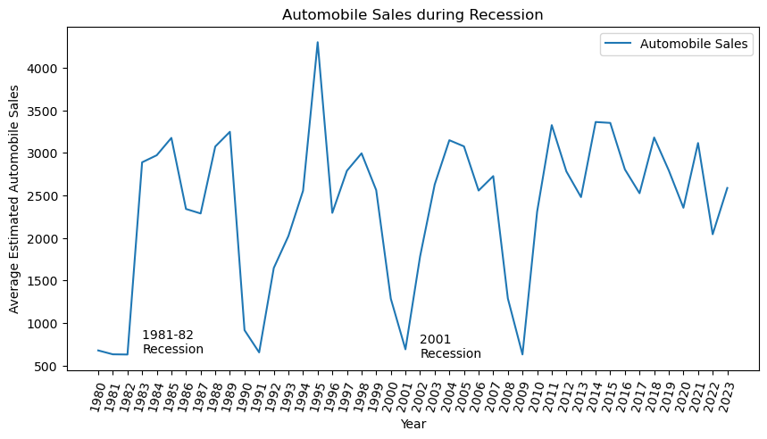

```python
#perform group by on year for average sales
df_new = df.groupby('Year')['Automobile_Sales'].mean().to_frame()
df_new.reset_index(inplace=True)

plt.figure(figsize=(10, 5))
sns.lineplot(data=df_new,x="Year",y="Automobile_Sales")
plt.xticks(list(range(1980,2024)), rotation = 75)
plt.xlabel('Year')
plt.ylabel('Average Estimated Automobile Sales')
plt.title('Automobile Sales during Recession')
plt.text(1983, 650, '1981-82 \nRecession')
plt.text(2002, 600, '2001 \nRecession')
plt.legend(["Automobile Sales"])
plt.show()
```

**Click here for Solution template**

```
plt.figure(figsize=(10, 6))
    df_line = ...............
    df_line.plot(kind = 'line')
    plt.xticks(list(range(1980,2024)), rotation = 75)
    plt.xlabel('..............')
    plt.ylabel('............')
    plt.title('...................')
    plt.text(1982, 650, '1981-82 Recession')
    plt.text(......, ..., '..............')
    plt.legend()
    plt.show()
```

Save this plot as "Line_Plot_1.png"  
*Hint: You can right lick on the plot and then click on "Save image as" option to save it on your local machine*

#### TASK 1.2: Plot different lines for categories of vehicle type and analyse the trend to answer the question Is there a noticeable difference in sales trends between different vehicle types during recession periods?

**Click here for a hint**

You will require:-  
create a separate dataframe where the column recession has a value of '1'  
to group the year, vehicle_type and calculate the average on the 'Automobile Sales'  
one way is to -  
use as_index as false else you will endup with multiple-indexed datafame  
later set year as index and groupby vehicle over Sales and plot  
make use of .plot() with kind = 'line'  
do not forget to include labels and title

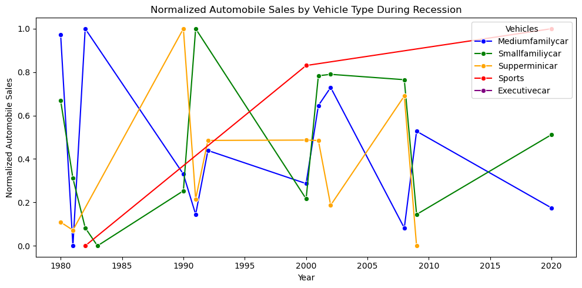

```python
# filter recission records
df_rec = df[df['Recession'] == 1]

#perform group by on year and vehicle type for average sales
df_cat = df_rec.groupby(["Year","Vehicle_Type"],as_index=False)["Automobile_Sales"].mean()

#perform group by on vehicle type for normalized sales
df_cat['Normalized_Sales'] = df_cat.groupby('Vehicle_Type')['Automobile_Sales'].transform(lambda x: (x - x.min()) / (x.max()-x.min()))

# set year as index
df_cat.set_index("Year",inplace=True)

# filter year, vehicle types and set color
years = df_cat.index.unique()
vehicles = df_cat["Vehicle_Type"].unique()
colors = ['blue','green','orange','red','purple']

# set fig size
plt.figure(figsize=(10, 5))

# loop over vehicles and perform line plot
for i, vehicle in enumerate(vehicles):
    df_v = df_cat[df_cat["Vehicle_Type"]==vehicle]
    sns.lineplot(data=df_v,x=df_v.index,y=df_v["Normalized_Sales"],marker='o',color=colors[i],label=vehicle)

plt.ylabel("Normalized Automobile Sales")
plt.xlabel("Year")
plt.title("Normalized Automobile Sales by Vehicle Type During Recession")
plt.legend(title='Vehicles', loc='upper right')
plt.tight_layout()
plt.show()
```

**Click here for Solution template**

```
# Assuming 'df' is your dataset
df_rec = df[df['Recession'] == 1]

# Calculate the average automobile sales by year and vehicle type during the recession
df_Mline = df_rec.groupby(['...', '...'], as_index=False)['...'].mean()

# Calculate the normalized sales by dividing by the average sales for each vehicle type
df_Mline['Normalized_Sales'] = df_Mline.groupby('....')['...'].transform(lambda x: x / x.mean())

# Set the 'Year' as the index
df_Mline.set_index('Year', inplace=True)

# Create the plot for each vehicle type
plt.figure(figsize=(12, 8))
for vehicle_type in df_Mline['Vehicle_Type'].unique():
    data = df_Mline[df_Mline['Vehicle_Type'] == vehicle_type]
    plt.plot(data.index, data['Normalized_Sales'], label=vehicle_type, marker='o')

# Highlight recession years
recession_years = df_rec['Year'].unique()
for year in recession_years:
    plt.axvline(x=year, color='gray', linestyle='--', alpha=0.5)

# Add labels, legend, and title
plt.legend(title="Vehicle Type", bbox_to_anchor=(1.05, 1), loc='upper left')
plt.ylabel("Normalized Sales")
plt.xlabel("Year")
plt.title("Normalized Automobile Sales by Vehicle Type During Recession")

# Show the plot
plt.tight_layout()
plt.show()
```

#### From the above plot, what insights have you gained on the sales of various vehicle types? Type in your answer below:

**Inference**

Save this plot as "Line_Plot_2.png"  
*Hint: You can right lick on the plot and then click on "Save image as" option to save it on your local machine*

### TASK 1.3: Use the functionality of **Seaborn Library** to create a visualization to compare the sales trend per vehicle type for a recession period with a non-recession period.

**Click here for a hint**

To visualize the average number of vehicles sold during recession and non-recession periods, you can use a bar chart  
You will need to group recession average Automobile_Sales and then plot it  
Make use of sns.barplot(x=x,y=y, data = df)

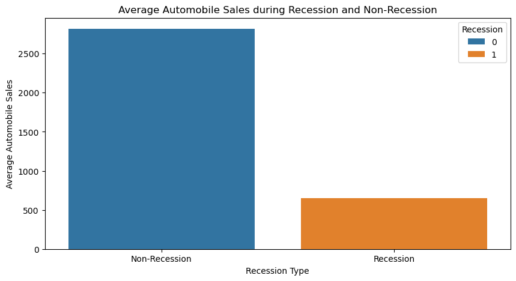

```python
# perform group by on recession for average autombile sales
new_df = df.groupby('Recession')['Automobile_Sales'].mean().reset_index()

plt.figure(figsize=(10,5))
sns.barplot(x='Recession', y='Automobile_Sales', hue='Recession',  data=new_df)
plt.xlabel('Recession Type')
plt.ylabel('Average Automobile Sales')
plt.title('Average Automobile Sales during Recession and Non-Recession')
plt.xticks(ticks=[0, 1], labels=['Non-Recession', 'Recession'])
plt.show()
```

**Click here for Solution template**

```
new_df = df.groupby('Recession')['Automobile_Sales'].mean().reset_index()

    # Create the bar chart using seaborn
    plt.figure(figsize=(.........., ............)
    sns.barplot(x='Recession', y='Automobile_Sales', hue='Recession',  data=new_df)
    plt.xlabel('............')
    plt.ylabel('...............')
    plt.title('Average Automobile Sales during Recession and Non-Recession')
    plt.xticks(ticks=[0, 1], labels=['Non-Recession', 'Recession'])
    plt.show()
```

### Now you want to compare the sales of different vehicle types during a recession and a non-recession period

We recommend that you use the functionality of **Seaborn Library** to create this visualization

**Click here for a hint**

To visualize sales of different vehicles during recession and non-recession periods, you can use a bar chart  
You will need to group Recession, Vehicle_Type for average Automobile_Sales and then plot it  
Make use of sns.barplot(x=x,y=y, data = df)

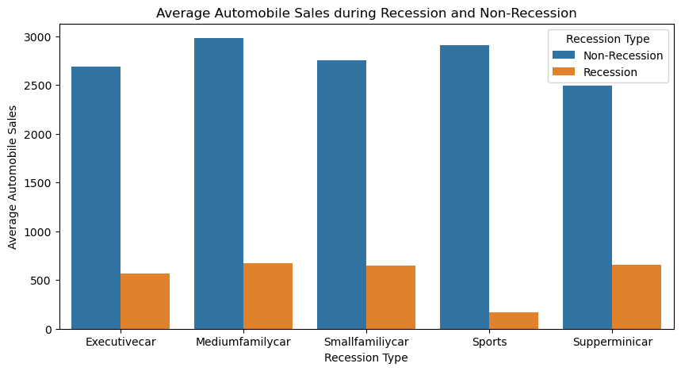

```python
# perform group by on recession and vehicle type for average autombile sales
new_df = df.groupby(['Recession','Vehicle_Type'])['Automobile_Sales'].mean().reset_index()
new_df["Recession"] = new_df["Recession"].replace([0,1],['Non-Recession', 'Recession'])

plt.figure(figsize=(10,5))
sns.barplot(x='Vehicle_Type', y='Automobile_Sales', hue='Recession',  data=new_df)
plt.xlabel('Recession Type')
plt.ylabel('Average Automobile Sales')
plt.title('Average Automobile Sales during Recession and Non-Recession')
plt.legend(title='Recession Type')
plt.show()
```

**Click here for Solution template**

```
# Filter the data for recessionary periods
    recession_data = df[df['Recession'] == 1]

    dd=df.groupby(['Recession','Vehicle_Type'])['Automobile_Sales'].mean().reset_index()

    # Calculate the total sales volume by vehicle type during recessions
    #sales_by_vehicle_type = recession_data.groupby('Vehicle_Type')['Automobile_Sales'].sum().reset_index()

    # Create the grouped bar chart using seaborn
    plt.figure(figsize=(10, 6))
    sns.barplot(x='......', y='........', hue='Vehicle_Type', data=dd)
    plt.xticks(ticks=[0, 1], labels=['Non-Recession', 'Recession'])
    plt.xlabel('.............')
    plt.ylabel('..............')
    plt.title('Vehicle-Wise Sales during Recession and Non-Recession Period')

    plt.show()
```

### From the above chart what insights have you gained on the overall sales of automobiles during recession? Type your answer below:-

**Inference**

From this plot, we can understand that there is a drastic decline in the overall sales of the automobiles during recession.  
However, the most affected type of vehicle is executivecar and sports

Save this plot as "Bar_Chart.png"  
*Hint: You can right lick on the plot and then click on "Save image as" option to save it on your local machine*

### TASK 1.4: Use sub plotting to compare the variations in GDP during recession and non-recession period by developing line plots for each period.

Now, you want to find more insights from the data to understand the reason.  
Plot a two line charts using subplotting to answer:-

#### How did the GDP vary over time during recession and non-recession periods?

Make use of add_subplot() from Matplotlib for this comparision.

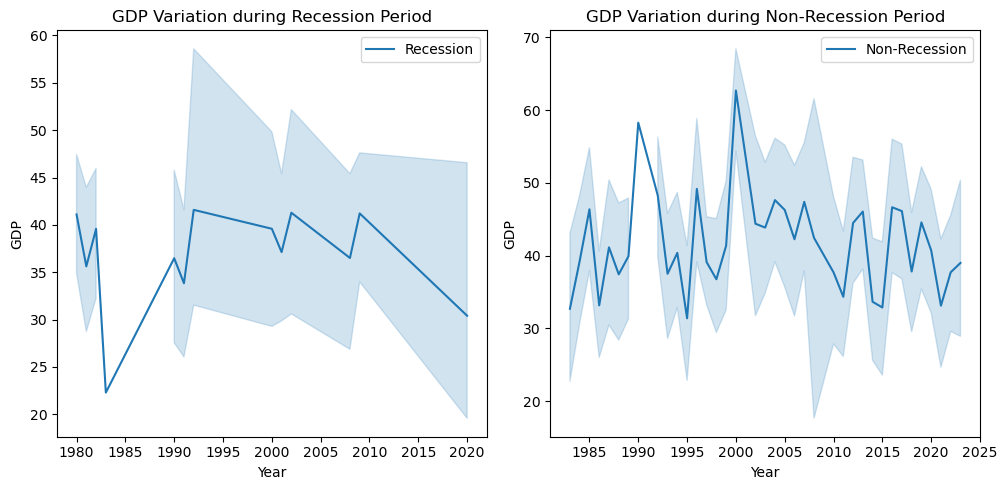

```python
#filter recession and non-recession data
rec_data = df[df['Recession'] == 1]
non_rec_data = df[df['Recession'] == 0]

# create fig with size
fig=plt.figure(figsize=(10, 5))

# create subplot axes
ax0 = fig.add_subplot(1, 2, 1)
ax1 = fig.add_subplot(1, 2, 2)

#subplot 1
sns.lineplot(x='Year', y='GDP', data=rec_data, label='Recession', ax=ax0)
ax0.set_xlabel('Year')
ax0.set_ylabel('GDP')
ax0.set_title('GDP Variation during Recession Period')

#subplot 1
sns.lineplot(x='Year', y='GDP', data=non_rec_data, label='Non-Recession', ax=ax1)
ax1.set_xlabel('Year')
ax1.set_ylabel('GDP')
ax1.set_title('GDP Variation during Non-Recession Period')

plt.tight_layout()
plt.show()
```

**Click here for Solution template**

```
#Create dataframes for recession and non-recession period
    rec_data = df[df['Recession'] == 1]
    non_rec_data = df[df['Recession'] == 0]

    #Figure
    fig=plt.figure(figsize=(12, 6))

    #Create different axes for subploting
    ax0 = fig.add_subplot(1, 2, 1) # add subplot 1 (1 row, 2 columns, first plot)
    ax1 = fig.add_subplot(... ,... ,... ) # add subplot 2 (1 row, 2 columns, second plot).

    #plt.subplot(1, 2, 1)
    sns.lineplot(x='Year', y='GDP', data=rec_data, label='Recession', ax=ax0)
    ax0.set_xlabel('Year')
    ax0.set_ylabel('GDP')
    ax0.set_title('GDP Variation during Recession Period')

    #plt.subplot(1, 2, 2)
    sns.lineplot(x='......', y='......', data=........, label='.........',ax=...)
    ax1.set_xlabel('.....')
    ax1.set_ylabel('.......')
    ax1.set_title('..........')

    plt.tight_layout()
    plt.show()

   #------------------------------------------------Alternatively--------------
   #Using subplot()
    plt.figure(figsize=(............, ..........))

    #subplot 1
    plt.subplot(1, 2, 1)
    sns.lineplot(x='.........', y='......', data=.........., label='......')
    plt.xlabel('.......')
    plt.ylabel('..........')
    plt.legend()
    #subplot 1
    plt.subplot(1, 2, 2)
    sns.lineplot(x='.........', y='......', data=.........., label='......')
    plt.xlabel('.......')
    plt.ylabel('..........')
    plt.legend()

    plt.tight_layout()
    plt.show()
```

### Inference

From this plot, it is evident that during recession, the GDP of the country was in a low range, might have afected the overall sales of the company  
Save this plot as "Subplot.png"  
*Hint: You can right lick on the plot and then click on "Save image as" option to save it on your local machine*

### TASK 1.5: Develop a Bubble plot for displaying the impact of seasonality on Automobile Sales.

How has seasonality impacted the sales, in which months the sales were high or low? Check it for non-recession years to understand the trend

##### Develop a Bubble plot for displaying Automobile Sales for every month and use Seasonality Weight for representing the size of each bubble

Title this plot as 'Seasonality impact on Automobile Sales'

**Click here for a hint**

You can create Bubble Chart by calling the scatter()  
Pass the 'Month' and 'Automobile_Sales' to the functions as x and y and then use Seasonality weight for size parameter

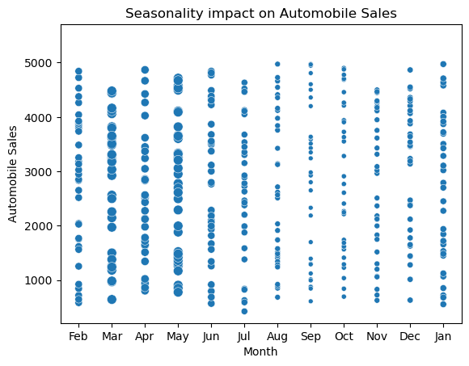

```python
non_rec_data = df[df['Recession'] == 0]

sns.scatterplot(data=non_rec_data, x='Month', y='Automobile_Sales', size=non_rec_data['Seasonality_Weight'],legend=False)

plt.xlabel('Month')
plt.ylabel('Automobile Sales')
plt.ylim(non_rec_data["Automobile_Sales"].min()*0.5, non_rec_data["Automobile_Sales"].median() * 2)
plt.title('Seasonality impact on Automobile Sales')
plt.show()
```

**Click here for Solution template**

```
non_rec_data = df[df['Recession'] == 0]

    size=non_rec_data['Seasonality_Weight'] #for bubble effect

    sns.scatterplot(data=non_rec_data, x='........', y='........', size=size)

    #you can further include hue='Seasonality_Weight', legend=False)

    plt.xlabel('Month')
    plt.ylabel('Automobile_Sales')
    plt.title('Seasonality impact on Automobile Sales')

    plt.show()
```

### TASK 1.6: Use the functionality of Matplotlib to develop a scatter plot to identify the correlation between average vehicle price relate to the sales volume during recessions.

#### From the data, develop a scatter plot to identify if there a correlation between consumer confidence and automobile sales during recession period?

Title this plot as 'Consumer Confidence and Automobile Sales during Recessions'

**Click here for a hint**

You can create dataframe where recession is '1'.  
Pass the 'Consumer_Confidence' and 'Automobile_Sales' to the plt.scatter()

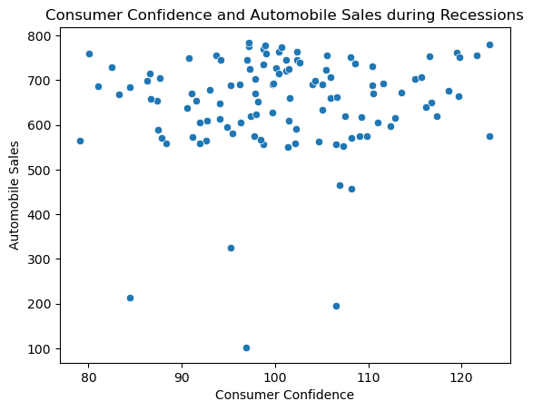

```python
df_rec = df[df["Recession"]==1]

sns.scatterplot(data=df_rec,x="Consumer_Confidence",y="Automobile_Sales")
plt.xlabel('Consumer Confidence')
plt.ylabel('Automobile Sales')
plt.title('Consumer Confidence and Automobile Sales during Recessions')
plt.show()
```

**Click here for Solution template**

```
#Create dataframes for recession and non-recession period
    rec_data = df[df['Recession'] == 1]
    plt.scatter(rec_data['Consumer_Confidence'], rec_data['Automobile_Sales'])

    plt.xlabel('.....')
    plt.ylabel('.......')
    plt.title('..........')
    plt.show()
```

### How does the average vehicle price relate to the sales volume during recessions?

Plot another scatter plot and title it as 'Relationship between Average Vehicle Price and Sales during Recessions'

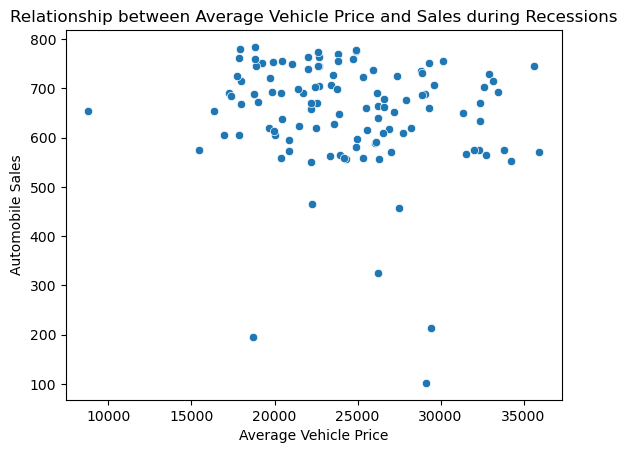

```python
rec_data = df[df['Recession'] == 1]

sns.scatterplot(data=rec_data,x='Price',y='Automobile_Sales')

plt.xlabel('Average Vehicle Price')
plt.ylabel('Automobile Sales')
plt.title('Relationship between Average Vehicle Price and Sales during Recessions')
plt.show()
```

**Click here for Solution template**

```
#Create dataframes for recession and non-recession period
    rec_data = df[df['Recession'] == 1]
    plt.scatter(recession_data['Price'], rec_data['Automobile_Sales'])

    plt.xlabel('.....')
    plt.ylabel('.......')
    plt.title('..........')
    plt.show()
```

### Inference

There is not much relation!  
Save this plot as "Scatter.png"  
*Hint: You can right lick on the plot and then click on "Save image as" option to save it on your local machine*

### TASK 1.7: Create a pie chart to display the portion of advertising expenditure of XYZAutomotives during recession and non-recession periods.

How did the advertising expenditure of XYZAutomotives change during recession and non-recession periods?

**Click here for a hint**

You can create two dataframe for recession and nonreccession period.  
Calculate the sum of Advertising_Expenditure for both dataframes  
Pass these total values to plt.pie(). May include labels as ['Recession', 'Non-Recession']  
Feel Free to customie the pie further  
title this plot as - Advertising Expenditure during Recession and Non-Recession Periods

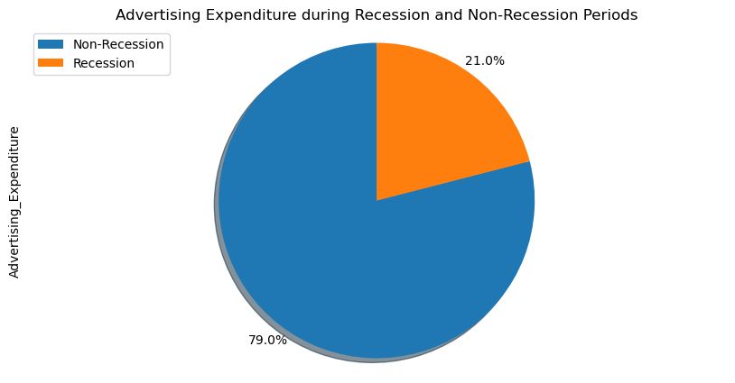

```python
df_exp = df.groupby("Recession")["Advertising_Expenditure"].sum().reset_index()

df_exp['Advertising_Expenditure'].plot(kind='pie',
                                       figsize=(10, 5),
                                       autopct='%1.1f%%',
                                       startangle=90,
                                       shadow=True,
                                       labels=None,
                                       pctdistance=1.12
                                       )
plt.title('Advertising Expenditure during Recession and Non-Recession Periods')
plt.axis('equal')
plt.legend(labels=['Non-Recession','Recession'], loc='upper left')
plt.show()
```

**Click here for Solution template**

```
# Filter the data
    Rdata = df[df['Recession'] == 1]
    NRdata = df[df['Recession'] == 0]

    # Calculate the total advertising expenditure for both periods
    RAtotal = Rdata['...........'].sum()
    NRAtotal = NRdata['...........'].sum()

    # Create a pie chart for the advertising expenditure
    plt.figure(figsize=(8, 6))

    labels = ['Recession', 'Non-Recession']
    sizes = [RAtotal, NRtotal]
    plt.pie(sizes, labels=labels, autopct='%1.1f%%', startangle=90)

    plt.title('...........................')

    plt.show()
```

#### From the above plot, what insights do you find on the advertisement expenditure during recession and non recession periods? Type your answer below:-

**Inference**

Save this plot as "Pie_1.png"  
*Hint: You can right lick on the plot and then click on "Save image as" option to save it on your local machine*

### TASK 1.8: Develop a pie chart to display the total Advertisement expenditure for each vehicle type during recession period.

Can we observe the share of each vehicle type in total expenditure during recessions?

**Click here for a hint**

You will be required to group vehicle type for sum of advertisement expenditure.  
the plot a pie with the data, May include relevant labels  
title this plot as - Share of Each Vehicle Type in Total Expenditure during Recessions

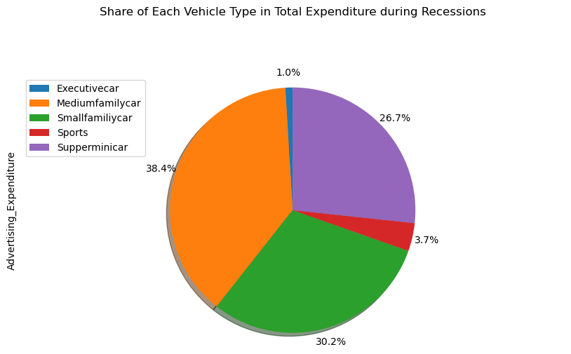

```python
df_rec = df[df["Recession"]==1]
df_exp = df_rec.groupby("Vehicle_Type")["Advertising_Expenditure"].sum().reset_index()

df_exp['Advertising_Expenditure'].plot(kind='pie',
                                       figsize=(10, 5),
                                       autopct='%1.1f%%',
                                       startangle=90,
                                       shadow=True,
                                       labels=None,
                                       pctdistance=1.12
                                       )

plt.title('Share of Each Vehicle Type in Total Expenditure during Recessions',y=1.2)
plt.axis('equal')
plt.legend(labels=df_exp["Vehicle_Type"], loc='upper left')
plt.show()
```

**Click here for Solution template**

```
# Filter the data
    Rdata = df[df['Recession'] == 1]

    # Calculate the sales volume by vehicle type during recessions
    VTexpenditure = Rdata.groupby('..........')['.............'].sum()

    # Create a pie chart for the share of each vehicle type in total expenditure during recessions
    plt.figure(figsize=(..., ...))

    labels = VTexpenditure.index
    sizes = VTexpenditure.values
    plt.pie(sizes, labels=labels, autopct='%1.1f%%', startangle=90)

    plt.title('....................')

    plt.show()
```

[output not shown]

### Inference

During recession the advertisements were mostly focued on low price range vehicle. A wise decision!  
Save this plot as "Pie_2.png"  
*Hint: You can right lick on the plot and then click on "Save image as" option to save it on your local machine*

### TASK 1.9: Develop a lineplot to analyse the effect of the unemployment rate on vehicle type and sales during the Recession Period.

Analyze the effect of the unemployment rate on vehicle type and sales during the Recession Period

#### You can create a lineplot and title the plot as 'Effect of Unemployment Rate on Vehicle Type and Sales'

**Click here for a hint**

Filter out the data for recession period  
Make use of lineplot() from seaborn and pass the relavent data

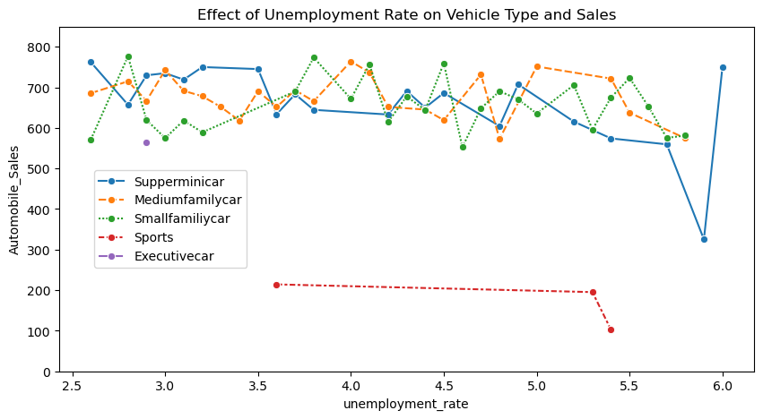

```python
df_rec = df[df["Recession"]==1]

plt.figure(figsize=(10, 5))
sns.lineplot(data=df_rec, x='unemployment_rate', y='Automobile_Sales',hue='Vehicle_Type', style='Vehicle_Type', markers='o', err_style=None)
plt.ylim(0,850)
plt.legend(loc=(0.05,.3))
plt.title('Effect of Unemployment Rate on Vehicle Type and Sales')
plt.show()
```

**Click here for Solution template**

```
df_rec = df[df['Recession']==1]
sns.lineplot(data=df_rec, x='..........', y='.........',
             hue='Vehicle_Type', style='Vehicle_Type', markers='o', err_style=None)
plt.ylim(0,850)
plt.legend(loc=(0.05,.3))
```

#### From the above plot, what insights have you gained on the sales of superminicar, smallfamilycar, mediumminicar? Type your answer below:-

**Inference**

Save this plot as "line_plot_3.png"  
*Hint: You can right lick on the plot and then click on "Save image as" option to save it on your local machine*

### OPTIONAL : TASK 1.10 Create a map on the hightest sales region/offices of the company during recession period

```python
import requests

async def download(url, filename):
    response = requests.get(url)
    if response.status_code == 200:
        with open(filename, "wb") as f:
            f.write(response.content)

path = 'https://cf-courses-data.s3.us.cloud-object-storage.appdomain.cloud/IBMDeveloperSkillsNetwork-DV0101EN-SkillsNetwork/Data%20Files/us-states.json'
await download(path, "us-states.json")

filename = "us-states.json"
```

#### You found that the datset also contains the location/city for company offices. Now you want to show the recession impact on various offices/city sales by developing a choropleth

```python
recession_data = df[df['Recession'] == 1]

# Calculate the total sales by city
sales_by_city = recession_data.groupby('City')['Automobile_Sales'].sum().reset_index()

# Create a base map centered on the United States
us_map = folium.Map(location=[37.0902, -95.7129], zoom_start=4)

# Create a choropleth layer using Folium
choropleth = folium.Choropleth(
    geo_data= 'us-states.json',
    data=sales_by_city,
    columns=['City', 'Automobile_Sales'],
    key_on='feature.properties.name',
    fill_color='YlOrRd',
    fill_opacity=0.7,
    line_opacity=0.2,
    legend_name='Automobile Sales during Recession'
).add_to(us_map)


# Add tooltips to the choropleth layer
choropleth.geojson.add_child(
    folium.features.GeoJsonTooltip(['name'], labels=True)
)

# Display the map
us_map
```

Make this Notebook Trusted to load map: File -> Trust Notebook

[interactive chart not shown]

**Click for Solution**

```
# Filter the data for the recession period and specific cities
    recession_data = data[data['Recession'] == 1]

    # Calculate the total sales by city
    sales_by_city = recession_data.groupby('City')['Automobile_Sales'].sum().reset_index()

    # Create a base map centered on the United States
    map1 = folium.Map(location=[37.0902, -95.7129], zoom_start=4)

    # Create a choropleth layer using Folium
    choropleth = folium.Choropleth(
        geo_data= 'us-states.json',  # GeoJSON file with state boundaries
        data=sales_by_city,
        columns=['City', 'Automobile_Sales'],
        key_on='feature.properties.name',
        fill_color='YlOrRd',
        fill_opacity=0.7,
        line_opacity=0.2,
        legend_name='Automobile Sales during Recession'
    ).add_to(map1)


    # Add tooltips to the choropleth layer
    choropleth.geojson.add_child(
        folium.features.GeoJsonTooltip(['name'], labels=True)
    )

    # Display the map
    map1
```

# Congratulations! You have completed the lab

## Authors

Dr. Pooja

Copyright © 2023 IBM Corporation. All rights reserved.